# Final_Project

```r
md_crime <- readr::read_csv(
  "https://umd0-my.sharepoint.com/:u:/g/personal/abennet7_umd_edu/EdnEVrxZcYNIlg2r9PDJ_DEB_yaAedY-bKTqtsxwqm3Ngw?download=1"
) |>
  janitor::clean_names()
```

```r
md_crime$incident_hour <- as.numeric(md_crime$incident_hour)
```

```r
mean(md_crime$incident_hour, na.rm = TRUE)
```

```
[1] 11.39711
```

```r
median(md_crime$incident_hour, na.rm = TRUE)
```

```
[1] 12
```

```r
max(md_crime$incident_hour, na.rm = TRUE)
```

```
[1] 23
```

```r
min(md_crime$incident_hour, na.rm = TRUE)
```

```
[1] 0
```

```r
sd(md_crime$incident_hour, na.rm = TRUE)
```

```
[1] 7.164607
```

Potential hypothesis that I could test include a. the majority of property crimes happen in the evening. **Revised in pt 2** Null hypothesis: The proportion of property crimes that occur when it is dark out, between the hours of 8 p.m. and 6 a.m., is less than or equal to 50%. H0 : p ≤ 0.50

Alternative hypothesis: The proportion of property crimes that occur when it is dark out, between the hours of 8 p.m. and 6 a.m., is greater than 50%. H1 : p > 0.50

```r
Property_total <- sum(md_crime$crime_against == "Property", na.rm = TRUE)
```

```r
Property_total
```

```
[1] 530914
```

```r
Property_dark <- sum(md_crime$crime_against == "Property" &
    (md_crime$incident_hour >= 20 | md_crime$incident_hour < 6),
    na.rm = TRUE)
```

```r
Property_dark
```

```
[1] 199511
```

```r
x <- Property_dark
n <- Property_total
```

```r
prop.test(x, n, p = 0.50, alternative = "greater", correct = FALSE)
```

```
    1-sample proportions test without continuity correction

data:  x out of n, null probability 0.5
X-squared = 32765, df = 1, p-value = 1
alternative hypothesis: true p is greater than 0.5
95 percent confidence interval:
 0.3746951 1.0000000
sample estimates:
        p
0.3757878
```

```r
binom.test(x, n, p = 0.50, alternative = "greater")
```

```
    Exact binomial test

data:  x and n
number of successes = 199511, number of trials = 530914, p-value = 1
alternative hypothesis: true probability of success is greater than 0.5
95 percent confidence interval:
 0.374694 1.000000
sample estimates:
probability of success
             0.3757878
```

**Test Interpretation** The alternative hypothesis is false because the proportion is less than 50% and the majority of property crimes did not happen when it was dark out. P = .37 which is lower than .50. So Since p < .50 we reject the alternative hypothesis.

```r
property_df <- md_crime %>%
  filter(crime_against == "Property")
```

```r
property_df$incident_hour <- as.numeric(property_df$incident_hour)
```

```r
hour_counts <- property_df %>%
  group_by(incident_hour) %>%
  summarise(count = n(), .groups = "drop")
```

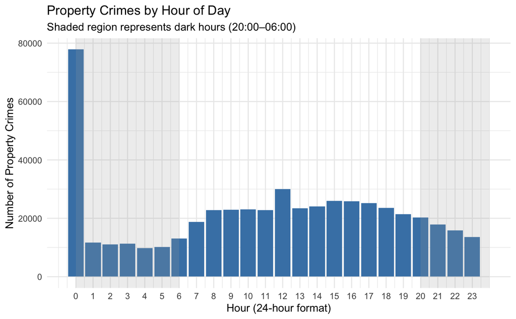

```r
ggplot(hour_counts, aes(x = incident_hour, y = count)) +
  geom_col(fill = "steelblue") +
  # Highlight dark hours (20–23 and 0–5)
  annotate("rect", xmin = 20, xmax = 24, ymin = -Inf, ymax = Inf,
           alpha = 0.2, fill = "darkgray") +
  annotate("rect", xmin = 0, xmax = 6, ymin = -Inf, ymax = Inf,
           alpha = 0.2, fill = "darkgray") +
  scale_x_continuous(breaks = 0:23) +
  labs(
    title = "Property Crimes by Hour of Day",
    subtitle = "Shaded region represents dark hours (20:00–06:00)",
    x = "Hour (24-hour format)",
    y = "Number of Property Crimes"
  ) +
  theme_minimal()
```

**Plot note**

I used AI for help generating this plot because I got stuck. Here is the link https://chatgpt.com/s/t_69268702b28c81919f8dff4f1b2a8583.

**Pitch** HL: Most property crimes don’t happen under the cover of darkness.

There is an assumption that robbers strike when people are sleeping at night, and there are less witnesses as it is dark out. However, based on Maryland Crime reports only 37% of property crimes happen while it is dark out. Rather than late-night break ins, the data suggests that these crimes happen during the day. This could be due to people being away from home at work, businesses being open, and neighborhoods are busy enough for the criminal to blend in.

My reporting plan would be to interview local police, victims of property crimes, neighborhood association leaders about how they try to protect their neighborhood, and business managers on how they protect their shop from theft.

Potential problems I could run in to is seasonal daylight changes. Based off my tests I used the hours 20 - 6 to be what defines “darkness” but this could change based on what season it is. There could also be a reporting bias in the data that property crimes that happen during the day are more likely to be reported because the victims are awake and able to report. Property crimes is also a broad category that does not only cover home break ins which could potentially be more common at night.